# Exploratory data analysis on SFARI SPARK datasets

```r
# read all csv files into data frames
csv_files <- list.files(pattern = "\\.csv$")
df_vector <- c()

for (csv_file in csv_files) {
  df_name <- sub("\\.csv$", "", csv_file)
  new_df_name <- gsub("-", "_", df_name)
  df <- read.csv(csv_file)
  assign(new_df_name, df, envir = .GlobalEnv)
  df_vector <- c(df_vector, new_df_name)
}

cat("Done. \n")
```

```
Done.
```

```r
df_with_asd <- c()

#cat("The following datasets contain the asd parameter: \n\n")

# no of entries in original data frames
for (df_name in df_vector) {
  current_df <- get(df_name)
  #cat(paste(df_name, " = \t", length(current_df$subject_sp_id), "\n"))

  # check if the df has a parameter called "asd"
  if ("asd" %in% colnames(current_df)) {
    df_with_asd <- c(df_with_asd, df_name)
  }
}
```

```r
# check which datasets have entries with asd="False" along with subject_sp_id parameter

df_with_asd_false <- c()

cat("The following datasets contain asd = 'False' entries along with Subject IDs: \n\n")

for (df_name in df_with_asd) {
  current_df <- get(df_name)
  false_res_dfname <- current_df[current_df$asd == "False", ]
  if (nrow(false_res_dfname) > 0) {
      if ("subject_sp_id" %in% colnames(current_df)) {
        cat(paste(df_name, ": ", nrow(false_res_dfname), "\n"))
        df_with_asd_false <- c(df_with_asd_false, df_name)
      }
  }
}
```

```
The following datasets contain asd = 'False' entries along with Subject IDs:

asr_2023_07_21 :  10629
background_history_sibling_2023_07_21 :  19679
basic_medical_screening_2023_07_21 :  112926
individuals_registration_2023_07_21 :  196835
scq_2023_07_21 :  26187
self_reported_genetic_diagnosis_2023_07_21 :  8625
vineland_3_2023_07_21 :  1
```

#### We also check for datasets with only asd="True" entries because they can possibly be linked to the previously listed datasets using subject_sp_id as key.

#### They may not be enough for classifiers but contain info on potential features.

```r
df_no_false <- setdiff(df_with_asd, df_with_asd_false)
print(df_no_false)
```

```
 [1] "background_history_adult_2023_07_21"
 [2] "background_history_child_2023_07_21"
 [3] "cbcl_1_5_2023_07_21"
 [4] "cbcl_6_18_2023_07_21"
 [5] "clinical_lab_results_2023_07_21"
 [6] "core_descriptive_variables_2023_07_21"
 [7] "dcdq_2023_07_21"
 [8] "predicted_iq_experimental_2023_07_21"
 [9] "rbsr_2023_07_21"
[10] "roles_2023_07_17"
[11] "srs_2_adult_self_2023_07_21"
```

# Comparing CBCL to datasets with asd='False' values

Based on **subject_sp_id** as key, the various datasets can be connected (joined).

What would the utility be? The linked rows would still be limited to asd=True values.

**For CBCL and ASR, are there common subject IDs, or is the sample set entirely different?**

```r
# Merge data frames based on subject_sp_id
merged_df <- merge(cbcl_1_5_2023_07_21, asr_2023_07_21, by = "subject_sp_id", all = FALSE)
nrow(merged_df)
```

0

**NO COMMON SUBJECTS.**

- ASR has info on non-ASD subjects
- CBCL only has info on ASD subjects

This comparison was similarly done for other datasets to obtain the following results.

| Dataset | CBCL1-5 | CBCL6-18 |
| --- | --- | --- |
| ASR | 0 | 0 |
| Background History Sibling | 0 | 0 |
| Basic Medical Screening | 2799 | 10172 |
| Individuals Registration | 0 | 0 |
| SCQ | 2779 | 10179 |
| Self-Reported Genetic Diagnosis | 453 | 1906 |
| Vineland-3 | 2515 | 9172 |

**What other datasets contain parameters that can be linked to ASD?**

# CBCL1-5

**How can the parameters be categorised?**

- Basic information and ASD status
- Basic social and academic skills
- Questionnaire (q001 to q112) --- 0/1/2
- Scores, ranges, percentile (integer, string, categorical)

**Which parameters can we explore for regression purposes?**

- Our desired output is True/False for ASD.
- Is there any quanitative parameter (e.g. ASD risk score) that we can predict based on other variables?
- Can we establish relationship between two 0,1,2 type parameters? Can that be used to classify patients?

### Boxplots of individual features (q001 to q099)

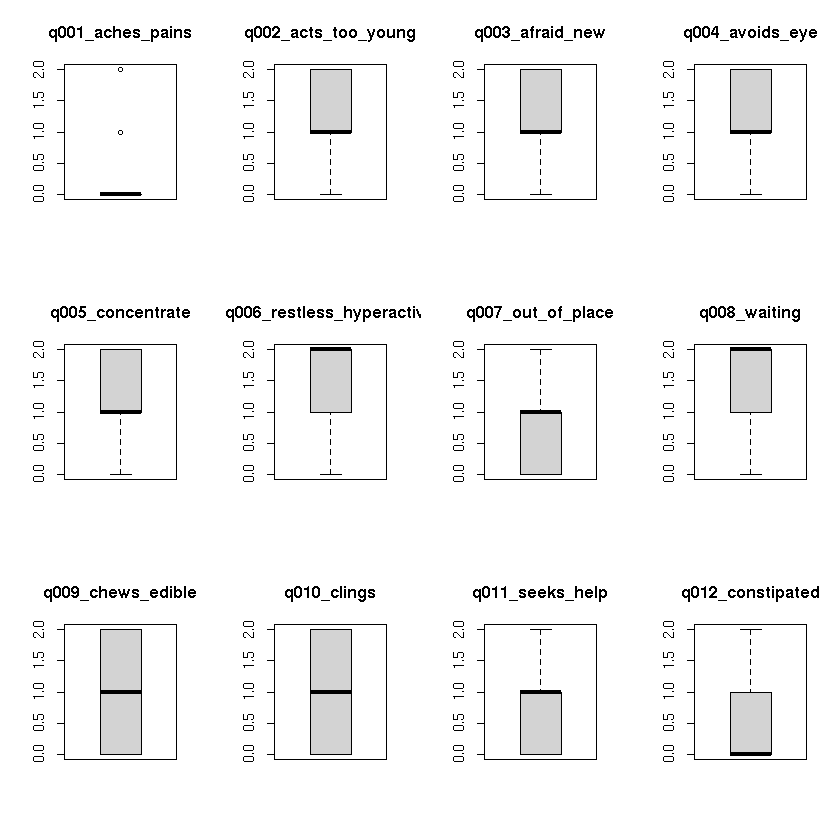

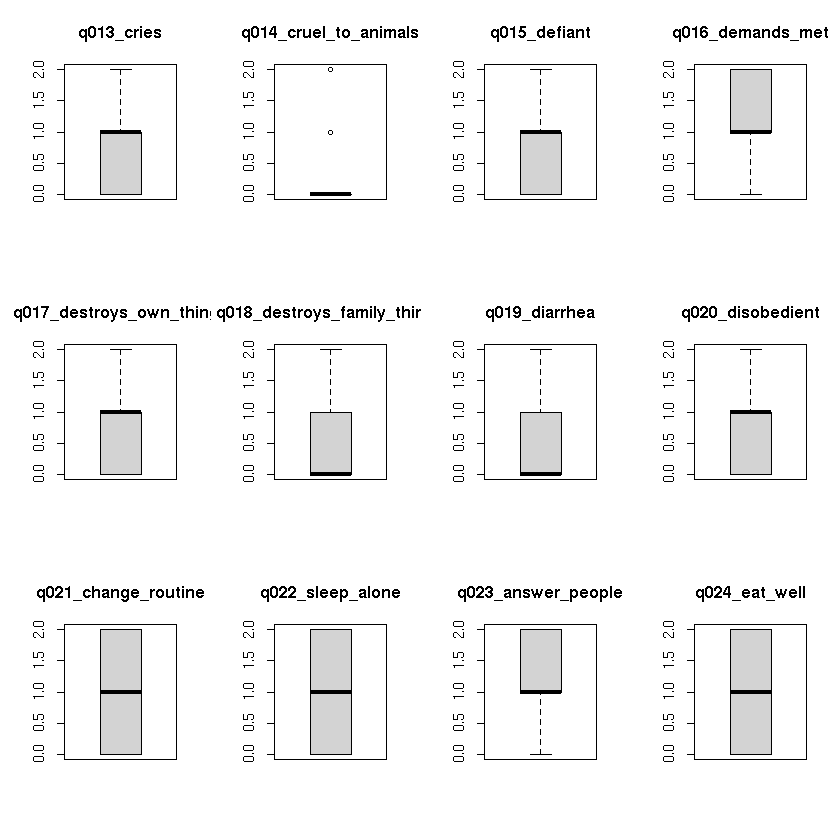

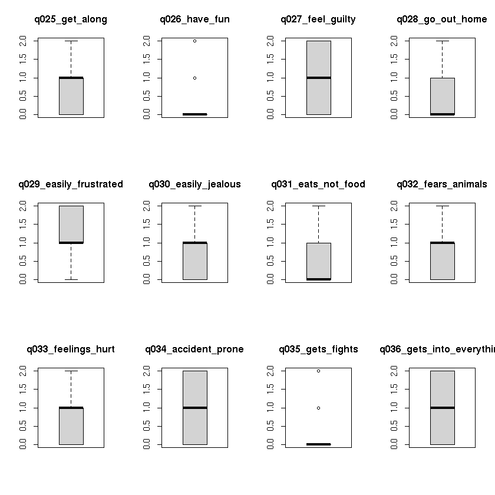

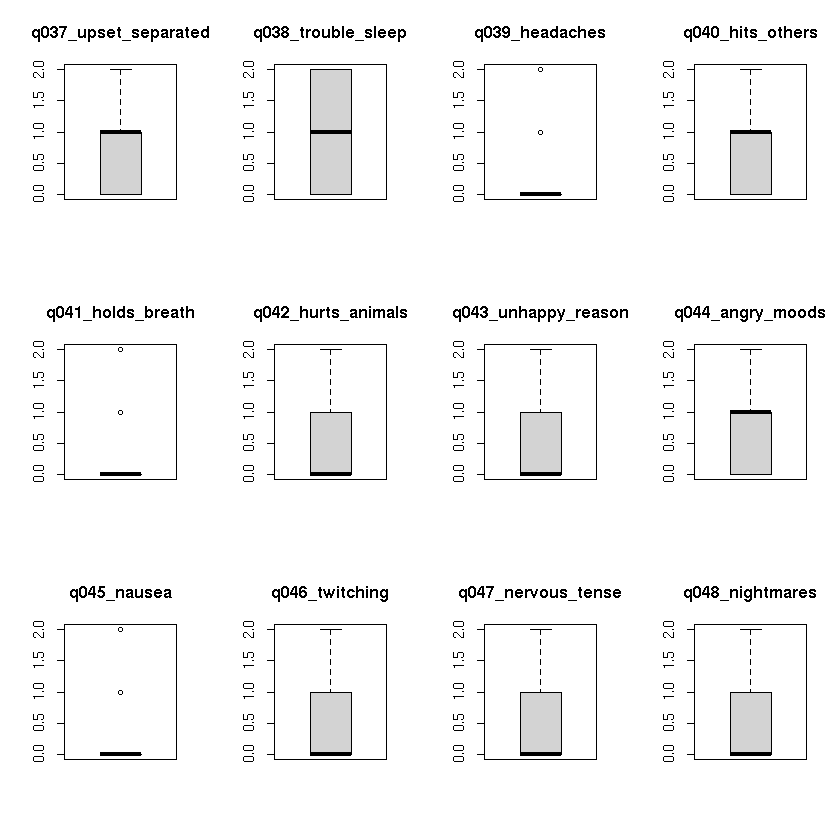

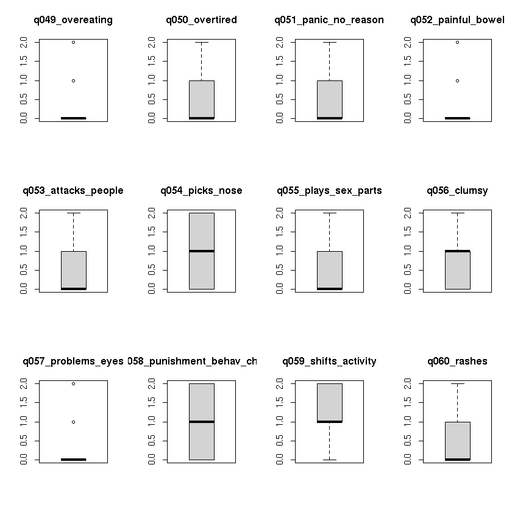

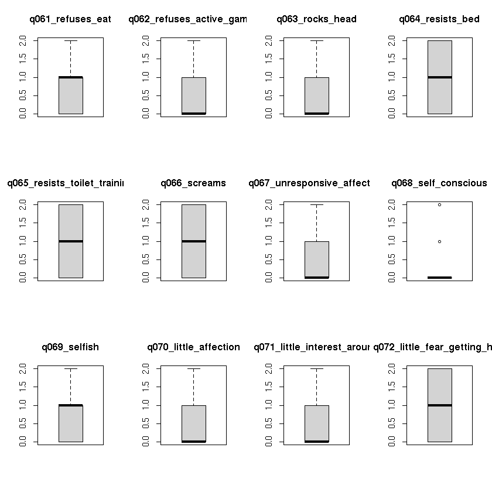

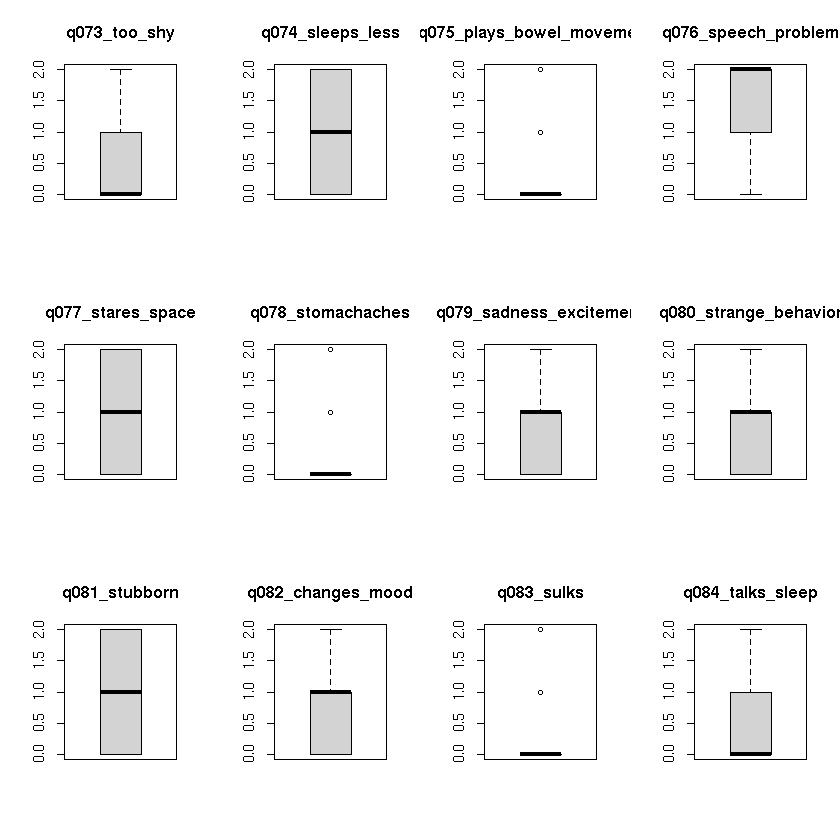

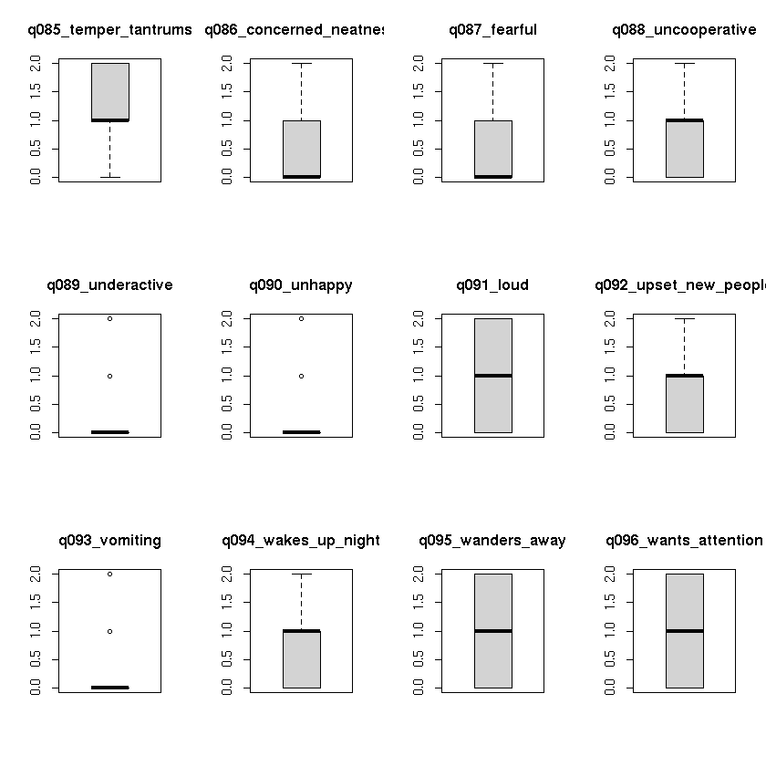

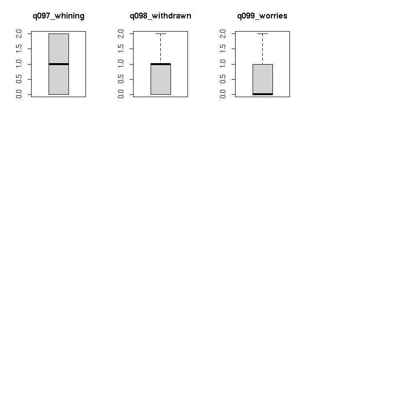

```r
# Assuming your_data_frame is the name of your data frame with 20 parameters
par(mfrow = c(3, 4))

# Get the column names of your_data_frame
param_names <- colnames(cbcl_1_5_2023_07_21)

count <- 0

# Loop through each parameter and create a box plot
for (i in 12:110) {
  boxplot(cbcl_1_5_2023_07_21[, i],
          main = paste(param_names[i]))
}
```

Parameters with median=0 may be less likely to be influencing ASD.

However, not all parameters are inherently negative. So their absence can also be a telltale sign of ASD.

# CBCL Data Exploration

- IDs are to be omitted
- CBCL validity flag ??
- percentile needs to be included. but for the same phenotype different measures are being used. should they be processed in any way?
- borderline clinical normal -> should be assigned integer form scores
- different sections of questions need to be scaled

# Data Cleaning

```r
# Convert blank cells to NA
cbcl_1_5_2023_07_21[cbcl_1_5_2023_07_21 == ""] <- NA

median(cbcl_1_5_2023_07_21$q001_aches_pains)
```

<NA>

- how to proceed with NA values?
  - drop rows?
  - forward fill? (not appropriate for sensitive data)

## Common features between ASR and CBCL

A lot of parameters are common between CBCL (Children) and ASR (Adults).

- **Maybe we can establish a relationship using ASR as training data and see if it can predict ASD status of CBCL data**
- we have to select only those parameters which are common between ASR and CBCL

```r
intersect(names(cbcl_1_5_2023_07_21), names(asr_2023_07_21))
```

1. 'subject_sp_id'

2. 'family_sf_id'

3. 'sex'

4. 'current_depend_adult'

5. 'asd'

6. 'age_at_eval_months'

7. 'age_at_eval_years'

8. 'q024_eat_well'

9. 'q046_twitching'

10. 'anxious_depressed_raw_score'

11. 'anxious_depressed_t_score'

12. 'anxious_depressed_percentile'

13. 'anxious_depressed_range'

14. 'somatic_complaints_raw_score'

15. 'somatic_complaints_t_score'

16. 'somatic_complaints_percentile'

17. 'somatic_complaints_range'

18. 'withdrawn_raw_score'

19. 'withdrawn_t_score'

20. 'withdrawn_percentile'

21. 'withdrawn_range'

22. 'attention_problems_raw_score'

23. 'attention_problems_t_score'

24. 'attention_problems_percentile'

25. 'attention_problems_range'

26. 'aggressive_behavior_raw_score'

27. 'aggressive_behavior_t_score'

28. 'aggressive_behavior_percentile'

29. 'aggressive_behavior_range'

30. 'internalizing_problems_raw_score'

31. 'internalizing_problems_t_score'

32. 'internalizing_problems_percentile'

33. 'internalizing_problems_range'

34. 'externalizing_problems_raw_score'

35. 'externalizing_problems_t_score'

36. 'externalizing_problems_percentile'

37. 'externalizing_problems_range'

38. 'total_problems_raw_score'

39. 'total_problems_t_score'

40. 'total_problems_percentile'

41. 'total_problems_range'

42. 'dsm5_depressive_problems_raw_score'

43. 'dsm5_depressive_problems_t_score'

44. 'dsm5_depressive_problems_percentile'

45. 'dsm5_depressive_problems_range'

46. 'dsm5_anxiety_problems_raw_score'

47. 'dsm5_anxiety_problems_t_score'

48. 'dsm5_anxiety_problems_percentile'

49. 'dsm5_anxiety_problems_range'

50. 'dsm5_attention_deficit_hyperactivity_raw_score'

51. 'dsm5_attention_deficit_hyperactivity_t_score'

52. 'dsm5_attention_deficit_hyperactivity_percentile'

53. 'dsm5_attention_deficit_hyperactivity_range'

**ONLY THE INTEGER PARAMETERS ARE USED FOR NOW.**

Encoding needs to be carried out on categorical data e.g. range = borderline|clinical|normal type questions.

## Improving the classifier

- Many more parameters are common between the two datasets.
- They are not being captured using the intersect command because the q number varies.
- Need to ensure that the parameters are correctly linked to each other based on keywords.
- May have to create a combined dataset of ASR and CBCL. Key to denote the original dataset. And combining of the questions. Will have to deal with missing data points wherever the questionnaire varies.

## **For now, we can try using a classifier to see if there is notable accuracy in prediction.**

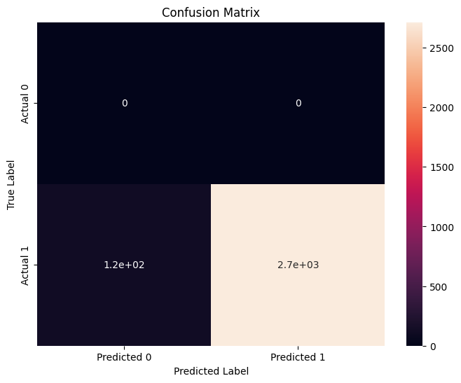

Fig. Confusion matrix obtained after using an **XGBoost** classifier using ASR as training data and CBCL as test data. (xgboost_cbcl_asr.py)

Accuracy: 0.957319  
Sensitivity: 0.957319  
Specificity: 0.000000  
Precision: 1.000000

**NOTE:**

- Since there are no False entries in the test data, specificity cannot be calculated.
- traintestsplit or cross validation was not carried out. variations of training data should be used.